# Thesis Question 1 & Question 2

### Map

Source: Hadley Wickham, D. N. (n.d.). 6 Maps. Retrieved December 02, 2021, from https://ggplot2-book.org/maps.html

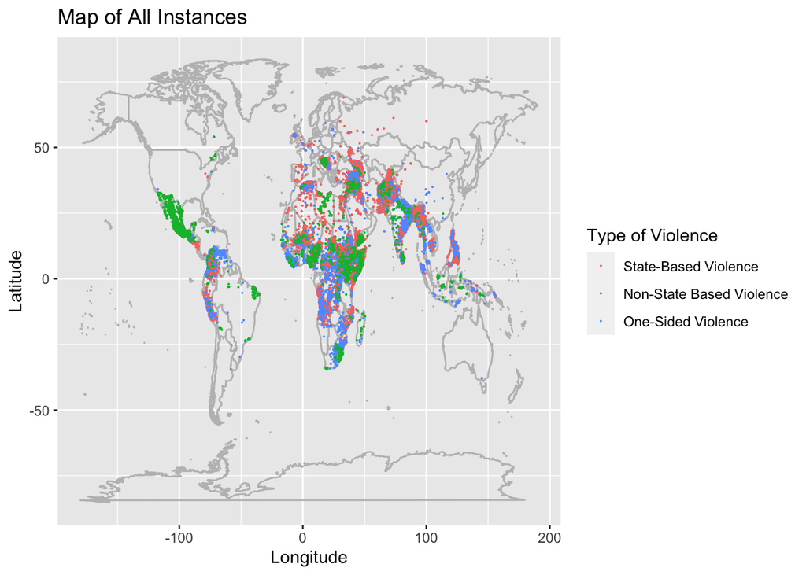

```r
#https://ggplot2-book.org/maps.html

#blank world map
world <- map_data("world")
map <- ggplot() + geom_polygon(data = world, aes(x=long, y = lat,group = group),fill=NA,color="grey")

#factor the type of violence column
ged211$type_of_violence <- as.factor(ged211$type_of_violence)

#add points to map
map + geom_point(data = ged211, aes(x = longitude, y = latitude, col = type_of_violence), size = 0.03) +
  ggtitle("Map of All Instances") +
  ylab("Latitude") +
  xlab("Longitude")+
  scale_color_discrete(name = "Type of Violence",labels = c("State-Based Violence", "Non-State Based Violence", "One-Sided Violence"))
```

### Total deaths over time by region

```r
gpd_region <- ged211 %>%
  dplyr::group_by(region,year) %>%
  dplyr::summarise(total = sum(best))
```

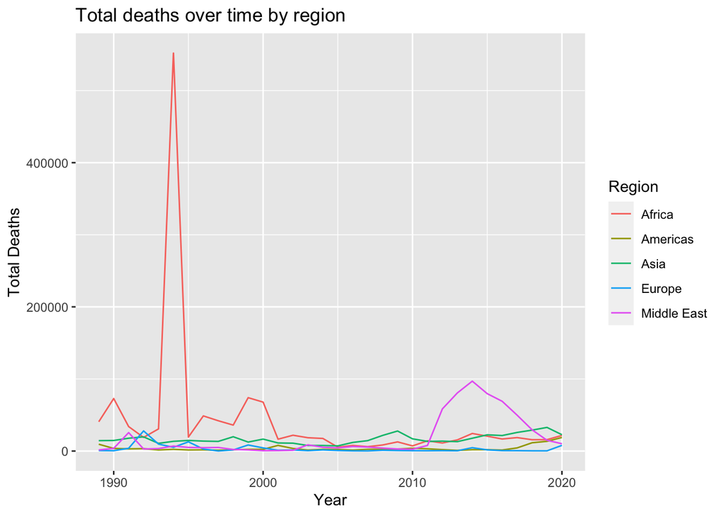

```r
gpd_region %>%
  ggplot( aes(x=year, y=total, group=region, color=region)) +
  geom_line() +
  ggtitle("Total deaths over time by region") +
  ylab("Total Deaths") +
  xlab("Year")+
  scale_color_discrete(name = "Region")
```

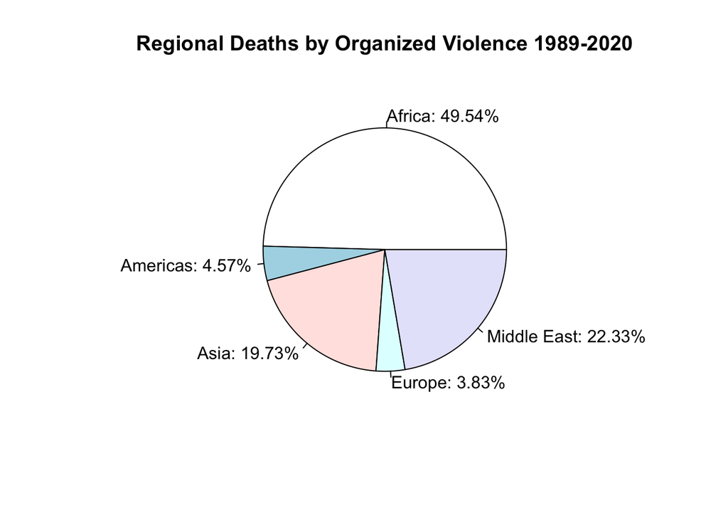

```r
gpd_region <- ged211%>%
  dplyr::group_by(region) %>%
  dplyr::summarize(total = sum(best))

pie_labels <- paste0(gpd_region$region, ": ", round(100 * gpd_region$total/sum(gpd_region$total), 2), "%")

pie(gpd_region$total,pie_labels, main="Regional Deaths by Organized Violence 1989-2020")
```

Again, we notice that the current situation is different to the last 30 years, with regions having more similar death tolls than previously. Let’s look at the situation in 2019 and 2020.

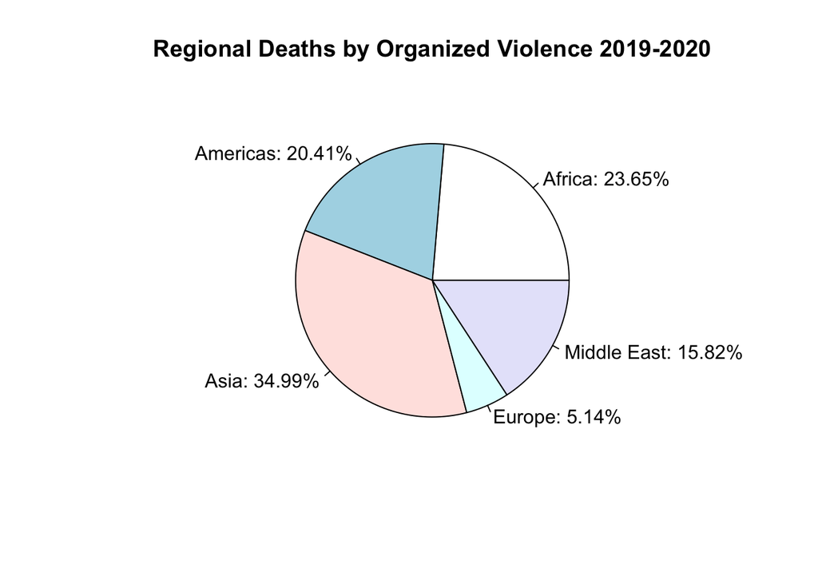

```r
#subset
gpd_region_2019 <- subset(ged211, year >= 2019)

#group and subtotal
gpd_region_2019 <- gpd_region_2019 %>%
  dplyr::group_by(region) %>%
  dplyr::summarize(total = sum(best))

pie_labels_2019 <- paste0(gpd_region_2019$region, ": ", round(100 * gpd_region_2019$total / sum(gpd_region_2019$total), 2), "%")

pie(gpd_region_2019$total,pie_labels_2019, main="Regional Deaths by Organized Violence 2019-2020")
```

### Types and regions

Source: Haaf, S. (2019, April 03). Easy multi-panel plots in R using facet_wrap() and facet_grid() from ggplot2. Retrieved from http://zevross.com/blog/2019/04/02/easy-multi-panel-plots-in-r-using-facet_wrap-and-facet_grid-from-ggplot2/

```r
#http://zevross.com/blog/2019/04/02/easy-multi-panel-plots-in-r-using-facet_wrap-and-facet_grid-from-ggplot2/

#One plot per region from 2000
since_2000 <- subset(ged211,year>=2000)

since_2000$type_of_violence <- as.factor(since_2000$type_of_violence)

types_regions <- since_2000 %>%
  dplyr::group_by(region,type_of_violence,year) %>%
  dplyr::summarize(total = sum(best))
types_regions
```

| region | type_of_violence | year | total |
| --- | --- | --- | --- |
| Africa | 1 | 2000 | 59709 |
| Africa | 1 | 2001 | 10608 |
| Africa | 1 | 2002 | 7267 |
| Africa | 1 | 2003 | 6453 |
| Africa | 1 | 2004 | 6034 |
| Africa | 1 | 2005 | 1620 |
| Africa | 1 | 2006 | 3721 |
| Africa | 1 | 2007 | 3456 |
| Africa | 1 | 2008 | 4714 |
| Africa | 1 | 2009 | 5650 |

[output cut: 285 more lines]

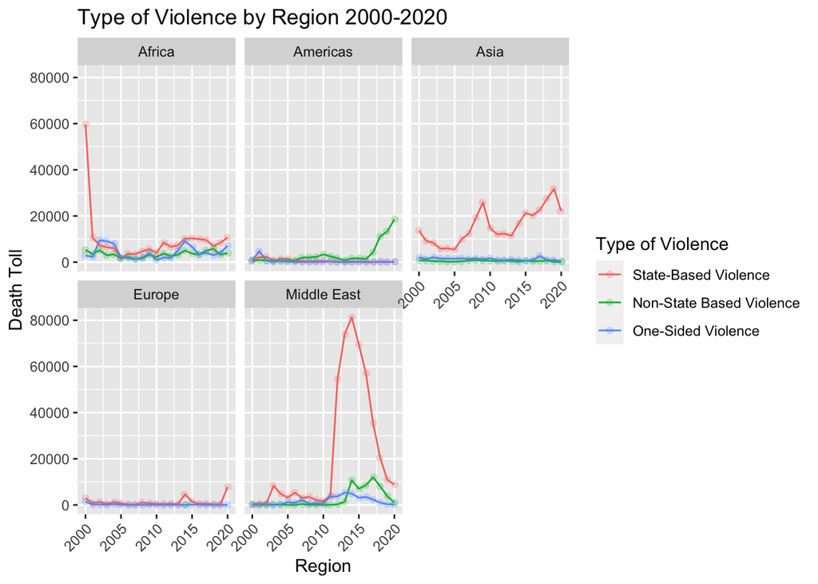

```r
types_regions %>%
  ggplot(aes(x=year, y=total,color=type_of_violence)) +
  geom_line() +
  geom_jitter(width=0.1,alpha=0.2) +
  xlab("region")+
  facet_wrap(~region) +
  theme(axis.text.x = element_text(angle = 45, hjust = 1)) +
  ggtitle("Type of Violence by Region 2000-2020")+
  scale_color_discrete(name = "Type of Violence",labels = c("State-Based Violence", "Non-State Based Violence", "One-Sided Violence"))+
  ylab("Death Toll") +
  xlab("Region")
```

We can see deaths by country

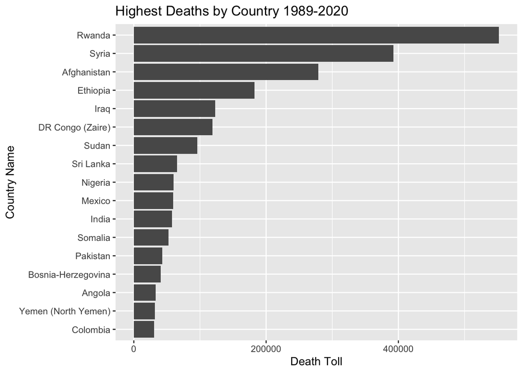

```r
#Group instances by country
countries <- ged211 %>%
  dplyr::group_by(country) %>%
  dplyr::summarise(total = sum(best))

#Subset instances with more than 10'000 deaths
subs <- subset(countries, total > 30000)


ggplot(data=subs,aes(x=reorder(country,total),y=total)) +
  geom_bar(stat ='identity')+
  coord_flip() +
  scale_fill_gradient(name="Number of Deaths")+
  labs(title = 'Highest Deaths by Country 1989-2020',y="Death Toll",x="Country Name")
```

We can see what this has been since 2010

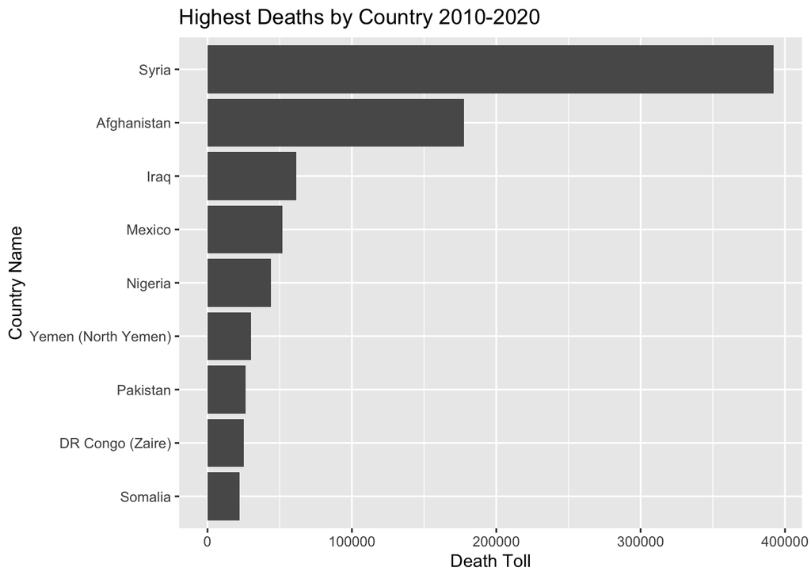

```r
#SINCE 2010
ged211_10 <- subset(ged211, year>=2010)

#Group instances by country
countries <- ged211_10 %>%
  dplyr::group_by(country) %>%
  dplyr::summarise(total = sum(best))

#Subset instances with more than 10'000 deaths
subs <- subset(countries, total > 20000)


ggplot(data=subs,aes(x=reorder(country,total),y=total)) +
  geom_bar(stat ='identity')+
  coord_flip() +
  scale_fill_gradient(name="Number of Deaths")+
  labs(title = 'Highest Deaths by Country 2010-2020',y="Death Toll",x="Country Name")
```

If we want to look at the most recent instances, we can subset the 2020 data

```r
#Select data from 2020 only
df2020 <- subset(ged211, year==2020)
df2020 <- cbind.data.frame(df2020$country,df2020$best)
colnames(df2020) <- c("country","best")


#aggregate subtotals
df_2020 <- aggregate(df2020$best, list(df2020$country), FUN=sum)
colnames(df_2020) <- c("country","total")

df_2020 <- df_2020 %>% arrange(desc(total))

head(df_2020)
```

|  | country | total |
| --- | --- | --- |
| 1 | Afghanistan | 20836 |
| 2 | Mexico | 16385 |
| 3 | Azerbaijan | 7623 |
| 4 | Syria | 5674 |
| 5 | Ethiopia | 3868 |
| 6 | DR Congo (Zaire) | 3831 |

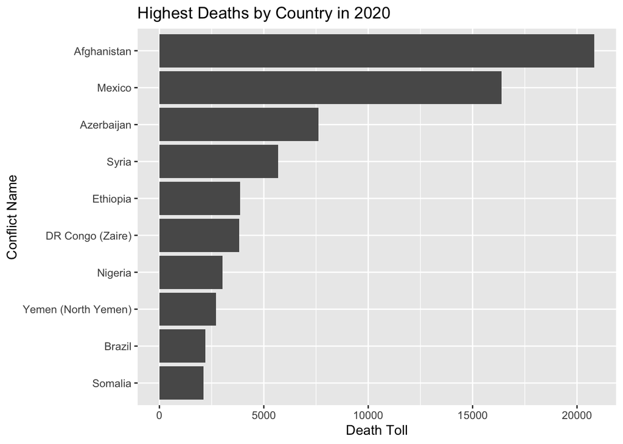

```r
ggplot(data=df_2020[1:10,],aes(x=reorder(country,total),y=total)) +
  geom_bar(stat ='identity')+
  coord_flip() +
  scale_fill_gradient(name="Number of Deaths")+
  labs(title = 'Highest Deaths by Country in 2020',y="Death Toll",x="Conflict Name")
```

## Distribution of death tolls in conflicts by countries

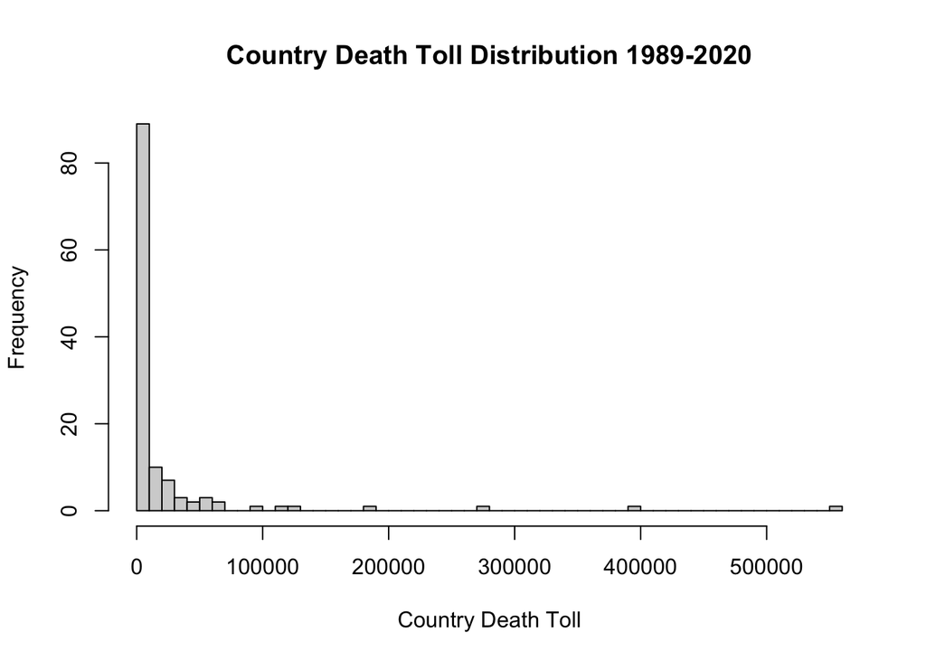

```r
df <- aggregate(ged211$best, list(ged211$country), FUN=sum)
hist (df$x, breaks=50, main="Country Death Toll Distribution 1989-2020",xlab="Country Death Toll")
```

We can check if this distribution looks similar to the last 10 years

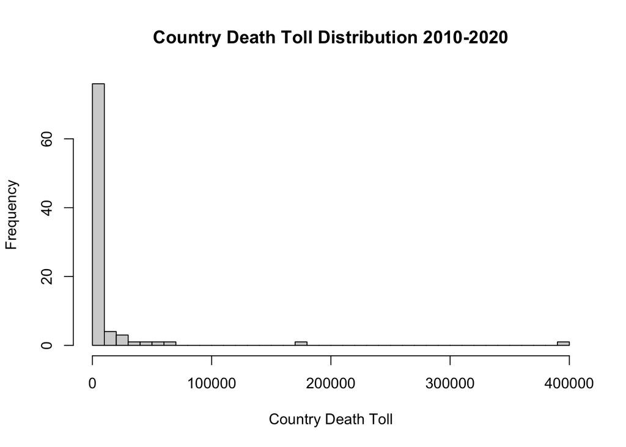

```r
df <- aggregate(ged211_10$best, list(ged211_10$country), FUN=sum)
hist (df$x, breaks=50, main="Country Death Toll Distribution 2010-2020",xlab="Country Death Toll")
```

## Libraries Used

### Documentation and functionality

readr: https://www.rdocumentation.org/packages/readr/versions/1.3.1 dplyr: https://www.rdocumentation.org/packages/dplyr/versions/0.7.8 ggplot2: https://ggplot2.tidyverse.org/ ggmap: https://www.rdocumentation.org/packages/ggmap/versions/3.0.0

## Sources Used

### For creating a grid with multiple plots:

Haaf, S. (2019, April 03). Easy multi-panel plots in R using facet_wrap() and facet_grid() from ggplot2. Retrieved from http://zevross.com/blog/2019/04/02/easy-multi-panel-plots-in-r-using-facet_wrap-and-facet_grid-from-ggplot2/

### For creating a map in R:

Hadley Wickham, D. N. (n.d.). 6 Maps. Retrieved December 02, 2021, from https://ggplot2-book.org/maps.html

### For ordering a horizontal bar chart:

Gregory Saxton, & Gavin Simpson (n.d.). Ordering of bars in ggplot. Retrieved from https://stackoverflow.com/questions/5967593/ordering-of-bars-in-ggplot